# 01_Statistics_python

**Statistics for Machine Learning**

|  | by Prof. Seungchul Lee iSystems Design Lab http://isystems.unist.ac.kr/ UNIST |
| --- | --- |

Table of Contents

[figure not shown]

# 1. Populations and Samples

- A **population** includes all the elements from a set of data
- A **parameter** is a quantity computed from a population
  - mean, $\mu$
  - variance, $\sigma^2$
- A **sample** is a subset of the population.
  - one or more observations
- A **statistic** is a quantity computed from a sample
  - sample mean, $\bar{x}$
  - sample variance, $𝑠^2$
  - sample correlation, $𝑆_{𝑥𝑦}$

# 2. Inference

- True population or process is modeled probabilistically.
- Sampling supplies us with realizations from probability model.
- Compute something, but recognize that we could have just as easily gotten a different set of realizations.

[figure not shown]

- We want to infer the characteristics of the true probability model from our **one** sample.

[figure not shown]

# 3. Law of Large Numbers

- Sample mean converges to the population mean as sample size gets large

$$ \bar{x} \rightarrow \mu_x \qquad \text{as} \qquad m \rightarrow \infty$$

- True for any probability density functions

[figure not shown]

- [wikipedia](http://en.wikipedia.org/wiki/Law_of_large_numbers)

## Sample Mean and Sample Size

- sample mean and sample variance

$$ \begin{align} \bar{x} &=\frac{x_1+x_2+...+x_m}{m}\\ s^2 &=\frac{\sum_{i=1}^{m}(x_i-\bar{x})^2}{m-1} \end{align} $$

- suppose $x \sim U[0,1]$

```python
import numpy as np
import matplotlib.pyplot as plt

%matplotlib inline
```

```python
# statistics
# numerically understand statisticcs

m = 100
x = np.random.rand(m,1)

#xbar = 1/m*np.sum(x, axis=0)
#np.mean(x, axis=0)
xbar = 1/m*np.sum(x)
np.mean(x)

varbar = (1/(m - 1))*np.sum((x - xbar)**2)
np.var(x)

print(xbar)
print(np.mean(x))
print(varbar)
print(np.var(x))
```

```
0.458759386078
0.458759386078
0.0749424145354
0.07419299039
```

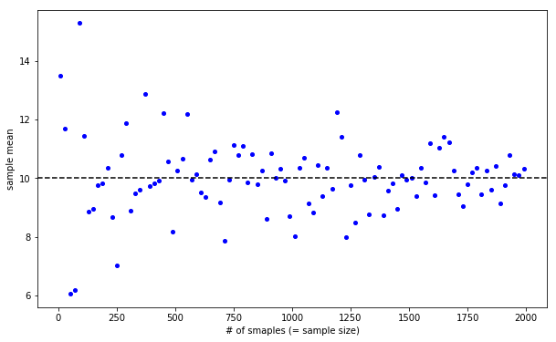

```python
# various sample size m
m = np.arange(10,2000,20)
means = []

for i in m:
    x = np.random.normal(10, 30, i)
    means.append(np.mean(x))

plt.figure(figsize=(10,6))
plt.plot(m, means, 'bo', markersize = 4)
plt.axhline(10, c='k', linestyle='dashed')
plt.xlabel('# of smaples (= sample size)', fontsize = 10)
plt.ylabel('sample mean', fontsize = 10)
plt.show()
```

# 4. Central limit theorem

- Sample mean (not samples) will be approixmatedly normally distributed as a sample size $m \rightarrow \infty$

$$ \bar{x} =\frac{x_1+x_2+...+x_m}{m}$$

- More samples provide more confidence (or less uncertainty)
- Note: true regardless of any distribution of population

$$ \bar{x} \rightarrow N\left(\mu_x,\left(\frac{\sigma}{\sqrt{m}}\right)^2 \right) $$

[figure not shown]

- [wikipedia](http://en.wikipedia.org/wiki/Central_limit_theorem)

## Variance Gets Smaller as $m$ is Larger

- Seems approximately Gaussian distributed
- numerically demostrate that sample mean follows the Gaussin distribution

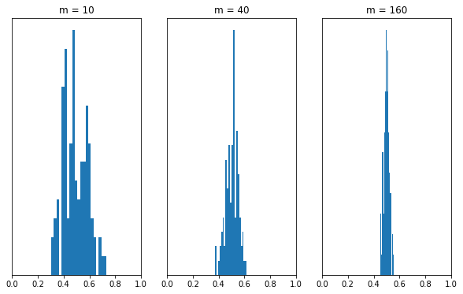

```python
N = 100
m = np.array([10, 40, 160])   # sample of size m

S1 = []   # sample mean (or sample average)
S2 = []
S3 = []

for i in range(N):
    S1.append(np.mean(np.random.rand(m[0],1)))
    S2.append(np.mean(np.random.rand(m[1],1)))
    S3.append(np.mean(np.random.rand(m[2],1)))

plt.figure(figsize=(10, 6))
plt.subplot(1,3,1), plt.hist(S1, 21), plt.xlim([0, 1]), plt.title('m = '+ str(m[0])), plt.yticks([])
plt.subplot(1,3,2), plt.hist(S2, 21), plt.xlim([0, 1]), plt.title('m = '+ str(m[1])), plt.yticks([])
plt.subplot(1,3,3), plt.hist(S3, 21), plt.xlim([0, 1]), plt.title('m = '+ str(m[2])), plt.yticks([])
plt.show()
```

# 5. How to Generate Random Numbers (Samples or data)

- Data sampled from population/process/generative model

```python
## random number generation (1D)
m = 1000;

# uniform distribution U(0,1)
x1 = np.random.rand(m,1);

# uniform distribution U(a,b)
a = 1;
b = 5;
x2 = a + (b-a)*np.random.rand(m,1);

# standard normal (Gaussian) distribution N(0,1^2)
# x3 = np.random.normal(0, 1, m)
x3 = np.random.randn(m,1);

# normal distribution N(5,2^2)
x4 = 5 + 2*np.random.randn(m,1);

# random integers
x5 = np.random.randint(1, 6, size = (1,m ));
```

## Histogram : graphical representation of data distribution

$ \Rightarrow$ rough sense of density of data

[figure not shown]

# 6. Multivariate Statistics

$$ x^{(i)} = \begin{bmatrix}x_1^{(i)} \\ x_2^{(i)}\\ \vdots \end{bmatrix}, \quad X = \begin{bmatrix} -& (x^{(i)})^T & -\\ - & (x^{(i)})^T & -\\ & \vdots & \\ - & (x^{(m)})^T & -\end{bmatrix}$$

- $m$ observations $\left(x^{(i)}, x^{(2)}, \cdots , x^{(m)}\right)$

$$ \begin{align*} \text{sample mean} \; \bar x &= \frac{x^{(1)} + x^{(2)} + \cdots + x^{(m)}}{m} = \frac{1}{m} \sum\limits_{i=1}^{m}x^{(i)} \\ \text{sample variance} \; S^2 &= \frac{1}{m-1} \sum\limits_{i=1}^{m}(x^{(i)} - \bar x)^2 \\ (\text{Note: } &\text{population variance} \; \sigma^2 = \frac{1}{N}\sum\limits_{i=1}^{N}(x^{(i)} - \mu)^2 \end{align*} $$

## 6.1. Correlation of two random variables

$$ \begin{align*} \text{Sample Variance} : S_x &= \frac{1}{m-1} \sum\limits_{i=1}^{m}\left(x^{(i)}-\bar x\right)^2 \\ \text{Sample Covariance} : S_{xy} &= \frac{1}{m-1} \sum\limits_{i=1}^{m}\left(x^{(i)}-\bar x\right)\left(y^{(i)}-\bar y \right)\\ \text{Sample Covariance matrix} : S &= \begin{bmatrix} S_x & S_{xy} \\ S_{yx} & S_y \end{bmatrix}\\ \text{sample correlation coefficient} : r &= \frac{S_{xy}}{ \sqrt {S_{xx}\cdot S_{yy}} } \end{align*}$$

- strength of **linear** relationship between two variables, $x$ and $y$
- assume

$$x_1 \leq x_2 \leq \cdots \leq x_n$$$$y_1 \leq y_2 \leq \cdots \leq y_n$$

$$ \begin{align*} & \begin{bmatrix} x_1 \\ y_1 \end{bmatrix}, \begin{bmatrix} x_2 \\ y_2 \end{bmatrix}, \cdots, \begin{bmatrix} x_n \\ y_n \end{bmatrix} \\ \\ \\ \\ & \begin{bmatrix} x_1 \\ y_n \end{bmatrix}, \begin{bmatrix} x_2 \\ y_{n-1} \end{bmatrix}, \cdots, \begin{bmatrix} x_n \\ y_1 \end{bmatrix} \\ \\ \\ \\ & \begin{bmatrix} x_i \\ y_j \end{bmatrix} \text{ random selection} \end{align*}$$

[figure not shown]

## 6.2. Correlation coefficient

- $+1 \to$ close to a straight line
- $-1 \to$ close to a straight line
- Indicate how close to a linear line, but
- No information on slope

$$0 \leq \left\lvert \text{ correlation coefficient } \right\rvert \leq 1$$$$\hspace{1cm}\begin{array}{Icr}\leftarrow\\ (\text{uncorrelated})\end{array} \quad \quad \quad \begin{array}{Icr}\rightarrow \\ (\text{linearly correlated})\end{array}$$

- does not tell anything about causality

## 6.3. Correlation Coefficient Plot

- Plots correlation coefficients among pairs of variables
- http://rpsychologist.com/d3/correlation/

[figure not shown]

## 6.4. Covariance Matrix

$$ \sum = \begin{bmatrix} E[(X_1-\mu_1)(X_1-\mu_1)]& E[(X_1-\mu_1)(X_2-\mu_2)] & \cdots &E[(X_1-\mu_1)(X_n-\mu_n)]\\ E[(X_2-\mu_2)(X_1-\mu_1)]& E[(X_2-\mu_2)(X_2-\mu_2)] & \cdots &E[(X_2-\mu_2)(X_n-\mu_n)]\\ \vdots & \vdots & \ddots & \vdots\\ E[(X_n-\mu_n)(X_1-\mu_1)]& E[(X_n-\mu_n)(X_2-\mu_2)] & \cdots &E[(X_n-\mu_n)(X_n-\mu_n)]\\ \end{bmatrix}$$

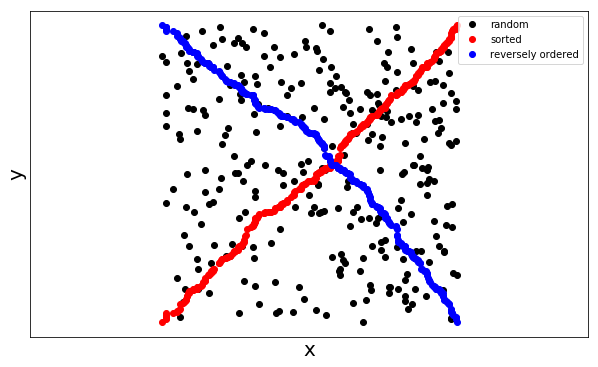

```
[[ 1.         -0.11803058]
 [-0.11803058  1.        ]]
[[ 1.          0.99883834]
 [ 0.99883834  1.        ]]
[[ 1.         -0.98848139]
 [-0.98848139  1.        ]]
```

```python
# correlation coefficient

m = 300
x = np.random.rand(m)
y = np.random.rand(m)

xo = np.sort(x)
yo = np.sort(y)
yor = -np.sort(-y)

plt.figure(figsize=(10, 6))
plt.plot(x, y, 'ko', label='random')
plt.plot(xo, yo, 'ro', label='sorted')
plt.plot(xo, yor, 'bo', label='reversely ordered')

plt.axis('equal')
plt.xticks([])
plt.yticks([])
plt.xlabel('x', fontsize=20)
plt.ylabel('y', fontsize=20)
plt.legend()
plt.show()

print(np.corrcoef(x,y))
print(np.corrcoef(xo,yo))
print(np.corrcoef(xo,yor))
```

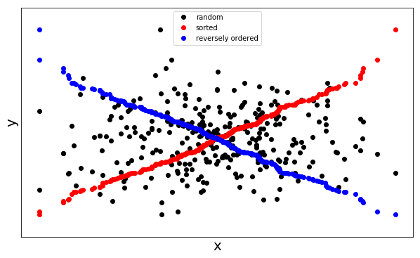

```
[[ 1.          0.01895451]
 [ 0.01895451  1.        ]]
[[ 1.          0.99555608]
 [ 0.99555608  1.        ]]
[[ 1.        -0.9957956]
 [-0.9957956  1.       ]]
```

```python
# correlation coefficient

m = 300
x = 2*np.random.randn(m)
y = np.random.randn(m)

xo = np.sort(x)
yo = np.sort(y)
yor = -np.sort(-y)

plt.figure(figsize=(10, 6))
plt.plot(x, y, 'ko', label='random')
plt.plot(xo, yo, 'ro', label='sorted')
plt.plot(xo, yor, 'bo', label='reversely ordered')

plt.xticks([])
plt.yticks([])
plt.xlabel('x', fontsize=20)
plt.ylabel('y', fontsize=20)
plt.axis('equal')
plt.legend()
plt.show()

print(np.corrcoef(x,y))
print(np.corrcoef(xo,yo))
print(np.corrcoef(xo,yor))
```

```python
%%javascript
$.getScript('https://kmahelona.github.io/ipython_notebook_goodies/ipython_notebook_toc.js')
```